# HW 3: Vector, Vector, Vector

蔡鉎驊 B08701244 工管系

2019-09-26 Rmd Source (for TAs)

# 1 基本題 (共 100 分)

## 1.1 向量向量向量 (共 40 分)

R 的向量式運算讓其非常適合用於統計學領域，因為需多統計學的運算與推導都會用到線性代數與向量。讓我們來探索向量式運算的便利之處吧～

1. (10 分) **內積**
   已知給定兩向量 $\mathbf{a} = [a1,~a2,~a3]$ 與 $\mathbf{b} = [b1,~b2,~b3]$，其內積為:
   $$\mathbf{a} \cdot \mathbf{b} = a1 \times b1 + a2 \times b2 + a3 \times b3$$
   請計算出 vec1 與 vec2 的內積：

   ```r
   vec1 <- c(1, -1, 0)
   vec2 <- c(pi, pi, exp(1))

   # 請在下方寫下你的程式碼
   vec1[1]*vec2[1]+vec1[2]*vec2[2]+vec1[3]*vec2[3]


   ```r
   # should print out:
   ```

   ```
   #> [1] 0
   ```

   ```
   #> [1] 0
   ```

2. (20 分) **修正姓氏**  
   下方為 2020 總統大選某投開票所開出的前 100 張選票 (儲存於 `votes`)，請將 `votes` 裡面的每個元素的第一個字母改成大寫 (e.g. `tsai` –> `Tsai`)。(hint: 你可以使用 `unique()` 找出 `votes` 裡面有哪些候選人)

   ```r
   votes <- c("gou", "ko", "wang", "wang", "wang", "wang", "ko", "wang", "tsai", "ko", "ko", "wang", "han", "wang", "ko", "han", "ko", "wang", "wang", "han", "tsai", "tsai", "ko", "tsai", "gou", "gou", "han", "ko", "han", "gou", "wang", "gou", "han", "gou", "wang", "wang", "han", "tsai", "han", "wang", "ko", "tsai", "wang", "ko", "ko", "ko", "tsai", "han", "wang", "gou", "han", "gou", "ko", "wang", "han", "ko", "tsai", "wang", "han", "tsai", "wang", "han", "gou", "tsai", "ko", "han", "wang", "tsai", "han", "tsai", "tsai", "tsai", "tsai", "wang", "gou", "tsai", "wang", "tsai", "han", "ko", "gou", "wang", "ko", "gou", "han", "ko", "wang", "gou", "gou", "ko", "ko", "gou", "wang", "ko", "ko", "ko", "han", "tsai", "ko", "wang")

   # 請在下方寫下你的程式碼
   votes[votes=="gou"]<-("Gou")
   votes[votes=="ko"]<-("Ko")
   votes[votes=="wang"]<-("Wang")
   votes[votes=="tsai"]<-("Tsai")
   votes[votes=="han"]<-("Han")

   votes


   # should print out:
   ```

   ```
   #> [1] "Gou" "Ko" "Wang" "Wang" "Wang" ...
   ```

   ```
   #>   [1] "Gou"  "Ko"   "Wang" "Wang" "Wang" "Wang" "Ko"   "Wang" "Tsai" "Ko"
   #>  [11] "Ko"   "Wang" "Han"  "Wang" "Ko"   "Han"  "Ko"   "Wang" "Wang" "Han"
   #>  [21] "Tsai" "Tsai" "Ko"   "Tsai" "Gou"  "Gou"  "Han"  "Ko"   "Han"  "Gou"
   #>  [31] "Wang" "Gou"  "Han"  "Gou"  "Wang" "Wang" "Han"  "Tsai" "Han"  "Wang"
   #>  [41] "Ko"   "Tsai" "Wang" "Ko"   "Ko"   "Ko"   "Tsai" "Han"  "Wang" "Gou"
   #>  [51] "Han"  "Gou"  "Ko"   "Wang" "Han"  "Ko"   "Tsai" "Wang" "Han"  "Tsai"
   #>  [61] "Wang" "Han"  "Gou"  "Tsai" "Ko"   "Han"  "Wang" "Tsai" "Han"  "Tsai"
   #>  [71] "Tsai" "Tsai" "Tsai" "Wang" "Gou"  "Tsai" "Wang" "Tsai" "Han"  "Ko"
   #>  [81] "Gou"  "Wang" "Ko"   "Gou"  "Han"  "Ko"   "Wang" "Gou"  "Gou"  "Ko"
   #>  [91] "Ko"   "Gou"  "Wang" "Ko"   "Ko"   "Ko"   "Han"  "Tsai" "Ko"   "Wang"
   ```

3. (10 分) (承上題) **得票率**  
   請依序計算出 `Tsai` 與 `Gou` 的得票率 (候選人得票數/總票數)

   ```r
   # 請在下方寫下你的程式碼
   sum(votes=='Tsai')/100
   sum(votes=="Gou")/100




   # should print out:
   ```

   ```
   #> [1] 0.18
   #> [1] 0.15
   ```

   ```
   #> [1] 0.18
   #> [1] 0.15
   ```

## 1.2 擲骰子 (共 30 分)

這次的作業 repo 中有個資料夾 `dice/`，裡面存放了 6 張圖片 (`1.png`, `2.png`, … `6.png`)，每張圖片代表骰子其中一面的點數。你的任務是使用 `sample()` 以及這些骰子圖片去「玩」擲骰子的遊戲。

1. (15 分) `sample()` 函數  
   請研究一下 `sample()` 這個函數，並使用 `sample()` 從 1, 2, 3, …, 6 裡面重複抽取出 10 個數字 (i.e. 擲 10 次骰子)，並將這 10 次抽出的數字以 numeric vector 的形式儲存在變數 `rolled` 當中

   ```r
   # 請在下方寫下你的程式碼

   rolled<-sample(c(1:6),10,replace=TRUE)
   # 請勿更動下方程式碼
   rolled

   # should print out something like:
   ```

   ```
   #> [1] 6 2 1 5 4 5 3 3 2 1
   ```

   ```r
   # Since it's random, the results should be different each time,
   # but there will always be ten numbers
   ```

   ```
   #>  [1] 6 1 4 6 3 4 5 6 2 1
   ```

2. (15 分) 動態嵌入圖片  
   在「擲」完骰子後，`rolled` 裡面應該儲存著 10 個範圍介於 1(含) 至 6(含) 的數字，而恰巧在 `dice/` 資料夾中的六張圖片的檔名也在 1 至 6 的數字中 (e.g. `2.png`)。因此，與其單純將 `rolled` 裡面的數字印出來，不如將這些數字轉變成骰子點數的圖片會更有趣。但要做到這點，你必須先提供這些骰子圖片的相對路徑，讓 R Markdown 可以依序將骰子點數的圖片插入文件中。舉例來說，你需要將 `6 2 1 5 4 5 3 3 2 1` 這個 numeric vector 變成一個 character vector: `"dice/6" "dice/2" "dice/1" "dice/5" "dice/4" "dice/5" "dice/3" "dice/3" "dice/2" "dice/1"`，如此，在將 Rmd Knit 成 HTML 時，電腦才找得到這些骰子圖片。你的任務是使用 `paste0()` 和 `rolled` 去製造出這個 character vector，並將此 character vector 儲存於 `img_paths`：

   ```r
   # 請修改下方程式碼，使 `img_paths` 印出的結果符合題目要求
   img_paths <- c("dice/1.png","dice/2.png","dice/3.png","dice/4.png",
                  "dice/5.png","dice/6.png")

   rolled<-sample(c(1:6),10,replace=TRUE)

   rolled[rolled == 1]<-("dice/1.png")
   rolled[rolled == 2]<-("dice/2.png")
   rolled[rolled == 3]<-("dice/3.png")
   rolled[rolled == 4]<-("dice/4.png")
   rolled[rolled == 5]<-("dice/5.png")
   rolled[rolled == 6]<-("dice/6.png")

   img_paths<-paste0(rolled)
   # 請勿更動下方程式碼
   img_paths

   # should print out something like:
   ```

   ```
   #>  [1] "dice/2.png" "dice/5.png" "dice/4.png" "dice/2.png" "dice/4.png"
   #>  [6] "dice/6.png" "dice/3.png" "dice/2.png" "dice/1.png" "dice/5.png"
   ```

   ```r
   # Since it's random, the results should be different each time,
   # but there will always be ten elements.
   # Also note that the elements should match the numbers stored in `rolled`
   ```

   ```
   #>  [1] "dice/1.png" "dice/4.png" "dice/2.png" "dice/4.png" "dice/4.png"
   #>  [6] "dice/5.png" "dice/6.png" "dice/2.png" "dice/6.png" "dice/5.png"
   ```

[figure not shown]

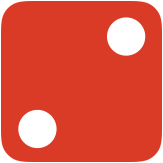

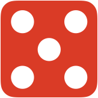

[figure not shown]

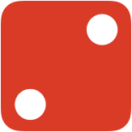

[figure not shown]

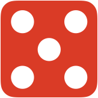

   ```r
   # 插入圖片用的，請勿更動此 Code Chunk 程式碼
   knitr::include_graphics(img_paths)
   ```

## 1.3 編號產生器 (30 分)

R 的向量式運算非常適合用來快速產生編號。你的任務是使用 `paste0()` 、 `rep()` 以及內建變數 `LETTERS` (A 至 Z、長度為 26 的 character vector) 去製造出一個長度為 78 的 character vector。這個 character vector 內的每個元素的形式為 `<大寫字母>_<數字>` (e.g., `A_1`, `K_3` )，且其**排序**應如下：

```
A_1 A_2 A_3 B_1 B_2 B_3 C_1 C_2 C_3 ... Z_1 Z_2 Z_3
```

1. 請先玩玩看 `rep()`，依據不同的輸入它會有許多令人意外的輸出。你可以嘗試看看：

   ```r
   rep(c("a", "b"), times = 2)
   rep(c("a", "b"), times = 1:2)
   rep(c("a", "b"), times = c(2, 2))
   ```

2. 這題會用到 Recycling 的概念

```r
# write your code here
x<-rep(c(LETTERS), times = c(3,3,3,3,3,3,3,3,3,3,3,3,3,3,3,3,3,3,3,3,3,3,3,3,3,3))

y<-rep(c(1:3),times=26)

paste0(x,"_",y)

# should print out:
```

```
#>  [1] "A_1" "A_2" "A_3" "B_1" "B_2" "B_3" "C_1" "C_2" "C_3"
#> [10] "D_1" "D_2" "D_3" "E_1" "E_2" "E_3" "F_1" "F_2" "F_3"
#> [19] "G_1" "G_2" "G_3" "H_1" "H_2" "H_3" "I_1" "I_2" "I_3"
#> [28] "J_1" "J_2" "J_3" "K_1" "K_2" "K_3" "L_1" "L_2" "L_3"
#> [37] "M_1" "M_2" "M_3" "N_1" "N_2" "N_3" "O_1" "O_2" "O_3"
#> [46] "P_1" "P_2" "P_3" "Q_1" "Q_2" "Q_3" "R_1" "R_2" "R_3"
#> [55] "S_1" "S_2" "S_3" "T_1" "T_2" "T_3" "U_1" "U_2" "U_3"
#> [64] "V_1" "V_2" "V_3" "W_1" "W_2" "W_3" "X_1" "X_2" "X_3"
#> [73] "Y_1" "Y_2" "Y_3" "Z_1" "Z_2" "Z_3"
```

```
#>  [1] "A_1" "A_2" "A_3" "B_1" "B_2" "B_3" "C_1" "C_2" "C_3" "D_1" "D_2"
#> [12] "D_3" "E_1" "E_2" "E_3" "F_1" "F_2" "F_3" "G_1" "G_2" "G_3" "H_1"
#> [23] "H_2" "H_3" "I_1" "I_2" "I_3" "J_1" "J_2" "J_3" "K_1" "K_2" "K_3"
#> [34] "L_1" "L_2" "L_3" "M_1" "M_2" "M_3" "N_1" "N_2" "N_3" "O_1" "O_2"
#> [45] "O_3" "P_1" "P_2" "P_3" "Q_1" "Q_2" "Q_3" "R_1" "R_2" "R_3" "S_1"
#> [56] "S_2" "S_3" "T_1" "T_2" "T_3" "U_1" "U_2" "U_3" "V_1" "V_2" "V_3"
#> [67] "W_1" "W_2" "W_3" "X_1" "X_2" "X_3" "Y_1" "Y_2" "Y_3" "Z_1" "Z_2"
#> [78] "Z_3"
```

# 2 進階選答題 (共 20 分)

> 這題使用到的 `replicate()` 屬於 R 的 `*apply` 家族 (這門課**不會介紹到**)。 若你是程式新手，建議可以先閱讀 Hands-on Programming with R 的 [Part 1](https://rstudio-education.github.io/hopr/project-1-weighted-dice.html)； 若有程式經驗，可以參考 [R 進階迴圈](https://blog.gtwang.org/r/r-advanced-loops/))

從國中數學我們知道，如果隨機擲兩個骰子並將這兩個骰子的點數加總，那我們得到 7 點的機率是 $\frac{6}{36}$、得到 6 點的機率是 $\frac{5}{36}$…。因此，若將兩骰子的點數和繪製成一個機率分佈圖 (x 軸為點數和、y 軸為點數和的機率)，我們會得到一個形狀如金字塔的分配 (見下圖)。

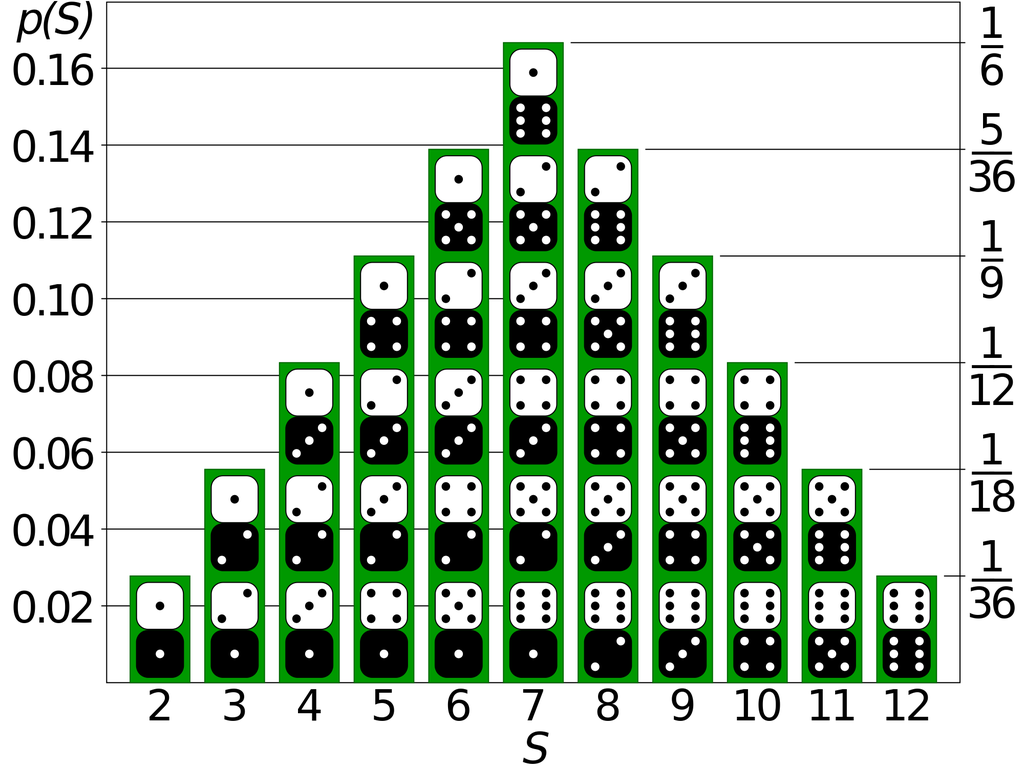

兩骰子點數和 (S) 之機率分佈

你的任務是使用 R 去「擲骰子」以模擬這個現象：  
請使用 `sample()`, `sum()`, `replicate()` 這 3 個函數去「擲」 1000 次骰子，並將結果儲存於 `sampling_exp`。`samling_exp` 裡面應該儲存著一個長度為 1000 的數列 (例如 `11 9 12 7 3 5 10 7 3 12 8 ...`，由於是隨機的，每次執行結果應會不同)

```r
# 請在下方寫下你的程式碼


# 請勿更動下方程式碼
sampling_exp
```

```
#> Error in eval(expr, envir, enclos): 找不到物件 'sampling_exp'
```

```r
# 請勿更動此 Code Chunk 程式碼
barplot(table(sampling_exp) / 1000,
        xlab = '兩骰子點數和',
        ylab = 'Prob',
        ylim = c(0 , 0.2))
```

[output not shown]

```
#> Error in table(sampling_exp): 找不到物件 'sampling_exp'
```